# Combita_Johana_Algoritmo_backpropagation

TAREA 1 - Author: Johana Cómbita Niño

a) Generalizar la función de backpropagation para que contemple la inclusión de una capa oculta. Aplicar la función al ejemplo de la clasificación circular y validar los resultados en el dominio x:[-1, 1], y:[-1, 1].

```python
import pandas as pd
import matplotlib.pyplot as plt
import numpy as np
import seaborn as sns
```

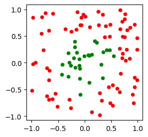

```python
#visualización de los datos
lin_cir = pd.read_csv("circle.csv", names=['x1', 'x2', 'y'])

ceros = np.where(lin_cir['y']==0)[0];
unos = np.where(lin_cir['y']==1)[0]

plt.figure(figsize = [3, 3])
plt.scatter(lin_cir['x1'][ceros], lin_cir['x2'][ceros], color = 'r', s=20)
plt.scatter(lin_cir['x1'][unos], lin_cir['x2'][unos], color = 'g', s=20)
```

```python
# Matriz de entrada y salida
a = lin_cir[['x1', 'x2']].T.values
b = lin_cir['y'].values.reshape(1, len(lin_cir['y'].values))

#Sigmoide: Función de activación usada en la regresión logística (0 y 1)
def sigmoid(x):
    return 1 / (1 + np.exp(-x))
#Derivada de la sigmoide: Se usa en el cálculo del gradiente para actualizar los pesos.
def d_sigmoid(x):
    return sigmoid(x)*(1-sigmoid(x))
```

```python
# Implementación de Backpropagation con descenso de gradiente y una capa oculta
def backprop(a, b, h=5, epochs=500, eta=0.1):
    ### Inicializar matrices y listas
    np.random.seed(1302)
    neurons = [np.shape(a)[0], h, np.shape(b)[0]]  # [2,5,1]
    weights = [np.random.uniform(low=-1, high=1, size=(neurons[i], neurons[i+1])) for i in range(len(neurons)-1)]  # [(2,5), (5,1)]
    bias = [np.random.uniform(low=-1, high=1, size=(neurons[i+1], 1)) for i in range(len(neurons)-1)]  # [(5,1), (1,1)]
    errors = []

    for i in range(epochs):
        ### Propagar hacia delante
        # entrada ponderada de la capa oculta
        B_hidden = np.dot(weights[0].T, a) + bias[0]  # (5, N)
        hidden = sigmoid(B_hidden)  # (5, N)

        # entrada ponderada de la capa de salida
        B_out = np.dot(weights[1].T, hidden) + bias[1]  # (1, N)
        b_out = sigmoid(B_out)  # (1, N)

        # Calculo de gradiente
        # ERROR (Diferencia entre real y predicha)
        d_error = b_out - b
        error = np.mean((d_error) ** 2)
        errors.append(error)

        # BACKPROPAGATION - capa de salida (pesos v y sesgos t)
        aux_delta = d_error * d_sigmoid(B_out)  # (1, N)
        v_delta_out = np.dot(hidden, aux_delta.T)  # (5,1)
        t_delta_out = aux_delta.sum(axis=1, keepdims=True)  # (1,1)

        # capa ocula (pesos w y sesgos b)
        aux_delta_w = np.dot(weights[1], aux_delta) * d_sigmoid(B_hidden)
        w_delta_hidden = np.dot(a, aux_delta_w.T)
        b_delta_hidden = aux_delta_w.sum(axis=1, keepdims=True)

        # Actualizar pesos y sesgos
        weights[0] -= eta * w_delta_hidden
        bias[0] -= eta * b_delta_hidden
        weights[1] -= eta * v_delta_out
        bias[1] -= eta * t_delta_out

        # Imprimir error cada 100 iteraciones
        if i % 100 == 0:
            print(f"Epoch {i}: Error = {error}")

    # Devolver valores aprendidos
    return weights, bias, errors
```

```
Epoch 0: Error = 0.20601910595878856
Epoch 100: Error = 0.19414525321628015
Epoch 200: Error = 0.13371849857655912
Epoch 300: Error = 0.0429617139350969
Epoch 400: Error = 0.023591642090778697
```

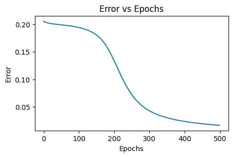

```python
# Ejecutar backpropagation
pesos, sesgos, errores = backprop(a, b, h=5, epochs=500, eta=0.1)

# Grafica error
plt.figure(figsize=[5, 3])
plt.plot(errores)
plt.xlabel('Epochs')
plt.ylabel('Error')
plt.title('Error vs Epochs')
plt.show()
```

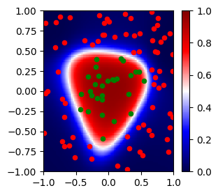

```python
# Visualización de la frontera de decisión
X1, X2 = np.meshgrid(np.linspace(-1, 1, 100), np.linspace(-1, 1, 100))
Z = sigmoid(np.dot(pesos[0].T, np.vstack([X1.ravel(), X2.ravel()])) + sesgos[0])
Z = sigmoid(np.dot(pesos[1].T, Z) + sesgos[1])

plt.figure(figsize = [3, 3])
p = plt.pcolormesh(X1, X2, Z.reshape(X1.shape), cmap = 'seismic', vmin = 0, vmax = 1)
plt.scatter(lin_cir['x1'][ceros], lin_cir['x2'][ceros], color = 'r', s=20)
plt.scatter(lin_cir['x1'][unos], lin_cir['x2'][unos], color = 'g', s=20)
plt.xlim([-1,1])
plt.ylim([-1,1])
plt.colorbar(p)
```

En la primera gráfica se observa, como el error va disminuyendo a medida que aumenta el número de épocas. Esto quiere decir que el modelo va aprendiendo cada vez mas hasta memorizar los datos, debido a que alcanza un error bastante bajo (0.02). Por su parte, la imagen muestra la frontera de decisión, identificando claramente dos regiones. En términos generales se observa que hay una adecuada clasificación.

b) Si se fija el número máximo de épocas en 1000. ¿Qué número de neuronas ocultas y qué valor de la tasa de aprendizaje (eta) es óptimo para este problema?(basta una solución aproximada).

```
Epoch 0: Error = 0.30761154510573596
Epoch 100: Error = 0.205275731296245
Epoch 200: Error = 0.20456465004258106
Epoch 300: Error = 0.2037492720301665
Epoch 400: Error = 0.20280013016588533
Epoch 500: Error = 0.20172891135859988
Epoch 600: Error = 0.20056912812075864
Epoch 700: Error = 0.19935176102945537
Epoch 800: Error = 0.19809405288054333
Epoch 900: Error = 0.19680691931410496
Epoch 0: Error = 0.30761154510573596
Epoch 100: Error = 0.20174383205721486
Epoch 200: Error = 0.19551311148544204
Epoch 300: Error = 0.18971180469843596
Epoch 400: Error = 0.18600708144974218
Epoch 500: Error = 0.1838237316995396
Epoch 600: Error = 0.18246266078109727
Epoch 700: Error = 0.18155136745389708
Epoch 800: Error = 0.18090117343114578
Epoch 900: Error = 0.18041189377173178
Epoch 0: Error = 0.30761154510573596
Epoch 100: Error = 0.19550027176192356
Epoch 200: Error = 0.18599705566324817
Epoch 300: Error = 0.18245678567088322
Epoch 400: Error = 0.1808976409637345
Epoch 500: Error = 0.18002503341105794
Epoch 600: Error = 0.1794506458207631
Epoch 700: Error = 0.179034084605866
Epoch 800: Error = 0.17871714790271637
Epoch 900: Error = 0.17847081324925543
Epoch 0: Error = 0.30761154510573596
Epoch 100: Error = 0.18395510847658814
Epoch 200: Error = 0.1817042611791305
Epoch 300: Error = 0.18097726531430147
Epoch 400: Error = 0.18062242907144183
Epoch 500: Error = 0.18038099577383643
Epoch 600: Error = 0.18019175261420273
Epoch 700: Error = 0.18003629358027395
Epoch 800: Error = 0.17990478071522265
Epoch 900: Error = 0.17979100166557221
```

[output cut: 345 more lines]

```
Epoch 500: Error = 0.026745060648249698
Epoch 600: Error = 0.022853509574829636
Epoch 700: Error = 0.020040356751933167
Epoch 800: Error = 0.017778381218534825
Epoch 900: Error = 0.015901389246862737
Epoch 0: Error = 0.21071707446450516
Epoch 100: Error = 0.2899944869977949
Epoch 200: Error = 0.28999413014262637
Epoch 300: Error = 0.2899937262309043
Epoch 400: Error = 0.289993265494709
Epoch 500: Error = 0.28999273529503145
Epoch 600: Error = 0.289992118992179
Epoch 700: Error = 0.28999139424076226
Epoch 800: Error = 0.2899905303373564
Epoch 900: Error = 0.28998948394753205
```

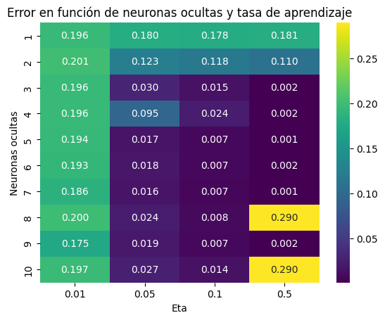

```python
n_neuronas = [1, 2, 3, 4, 5, 6, 7, 8, 9, 10]
etas = [0.01, 0.05, 0.1, 0.5]

errores = np.zeros((len(n_neuronas), len(etas)))

#Iteración sobre las combinaciones de neuronas ocultas y tasas de aprendizaje
for i, n in enumerate(n_neuronas):
    for j, eta in enumerate(etas):
        weights, bias, error_list = backprop(a, b, h=n, epochs=1000, eta=eta)
        errores[i, j] = error_list[-1]

#Visualización de los errores
sns.heatmap(errores, xticklabels=etas, yticklabels=n_neuronas, annot=True, fmt=".3f", cmap='viridis')
plt.xlabel('Eta')
plt.ylabel('Neuronas ocultas')
plt.title('Error en función de neuronas ocultas y tasa de aprendizaje')
plt.show()
```

Las neuronas de la capa oculta permiten que la red aprenda relaciones no lineales. En este problema, considerar pocas podría hacer que el modelo no capture la complejidad y muchas podría hacer que sobreajuste. Por su parte, la tasa de aprendizaje (eta) es el tamaño de los pasos que se dan en la dirección del gradiente durante el descenso. Un valor muy alto puede generar inestabilidad y saltos, y muy bajo un entrenamiento muy lento pudiendo no converger en las épocas establecidas.

La imagen ayuda explorar como se comporta el error en función del número de neuronas y la tasa de aprendizaje. En esta se observa que una tasa de aprendizaje de 0.5 y entre 3-7 neuronas podrían considerarse valores oportunos, donde el error es bastante bajo.

Probemos el modelo con 5 neuronas y tasa de aprendizaje de 0.5.

```
Epoch 0: Error = 0.20601910595878856
Epoch 100: Error = 0.04784681511966699
Epoch 200: Error = 0.008333715661911071
Epoch 300: Error = 0.005082875295173177
Epoch 400: Error = 0.0035943792933983794
Epoch 500: Error = 0.002728297332855936
Epoch 600: Error = 0.002163486297259668
Epoch 700: Error = 0.0017695041336568537
Epoch 800: Error = 0.0014817255629317482
Epoch 900: Error = 0.001264129457719949
```

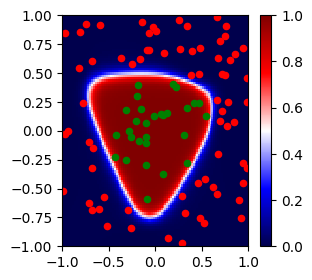

```python
pesos, sesgos, errores = backprop(a, b, h=5, epochs=1000, eta=0.5)

X1, X2 = np.meshgrid(np.linspace(-1, 1, 100), np.linspace(-1, 1, 100))
Z = sigmoid(np.dot(pesos[0].T, np.vstack([X1.ravel(), X2.ravel()])) + sesgos[0])
Z = sigmoid(np.dot(pesos[1].T, Z) + sesgos[1])

plt.figure(figsize = [3, 3])
p = plt.pcolormesh(X1, X2, Z.reshape(X1.shape), cmap = 'seismic', vmin = 0, vmax = 1)
plt.scatter(lin_cir['x1'][ceros], lin_cir['x2'][ceros], color = 'r', s=20)
plt.scatter(lin_cir['x1'][unos], lin_cir['x2'][unos], color = 'g', s=20)
plt.xlim([-1,1])
plt.ylim([-1,1])
plt.colorbar(p)
```

La imagen muestra una mejora en la clasificación con respecto al punto anterior donde teniamos h=5, epochs=500, eta=0.1, teniendo en cuenta este conjunto de datos. Aumentando el número de épocas, y con los valores óptimos de neuronas y tasa de aprendizaje, se tiene un mejor error (0.001).

c) Incluir un término de inercia en el método de backpropagation.

```python
def backprop_with_momentum(a, b, h=5, epochs=1000, eta=0.5, alpha=0.9):
    # Inicializar matrices y listas
    np.random.seed(1302)
    neurons = [np.shape(a)[0], h, np.shape(b)[0]]  # [2,5,1]
    weights = [np.random.uniform(low=-1, high=1, size=(neurons[i], neurons[i+1])) for i in range(len(neurons)-1)]  # [(2,5), (5,1)]
    bias = [np.random.uniform(low=-1, high=1, size=(neurons[i+1], 1)) for i in range(len(neurons)-1)]  # [(5,1), (1,1)]
    errors = []

    # Inicializar cambios anteriores (inercia) en cero
    weight_updates = [np.zeros_like(w) for w in weights]
    bias_updates = [np.zeros_like(b) for b in bias]

    for i in range(epochs):
        # Propagación hacia adelante
        B_hidden = np.dot(weights[0].T, a) + bias[0]  # (5, N)
        hidden = sigmoid(B_hidden)  # (5, N)
        B_out = np.dot(weights[1].T, hidden) + bias[1]  # (1, N)
        b_out = sigmoid(B_out)  # (1, N)

        # Cálculo del error
        d_error = b_out - b
        error = np.mean((d_error) ** 2)
        errors.append(error)

        # Retropropagación - capa de salida
        aux_delta = d_error * d_sigmoid(B_out)  # (1, N)
        v_delta_out = np.dot(hidden, aux_delta.T)  # (5,1)
        t_delta_out = aux_delta.sum(axis=1, keepdims=True)  # (1,1)

        # Retropropagación - capa oculta
        aux_delta_w = np.dot(weights[1], aux_delta) * d_sigmoid(B_hidden)
        w_delta_hidden = np.dot(a, aux_delta_w.T)
        b_delta_hidden = aux_delta_w.sum(axis=1, keepdims=True)

        # Actualización de pesos y sesgos con inercia
        weight_updates[0] = alpha * weight_updates[0] - eta * w_delta_hidden
        bias_updates[0] = alpha * bias_updates[0] - eta * b_delta_hidden
        weight_updates[1] = alpha * weight_updates[1] - eta * v_delta_out
        bias_updates[1] = alpha * bias_updates[1] - eta * t_delta_out

        weights[0] += weight_updates[0]
        bias[0] += bias_updates[0]
        weights[1] += weight_updates[1]
        bias[1] += bias_updates[1]

        # Imprimir error cada 100 iteraciones
        if i % 100 == 0:
            print(f"Epoch {i}: Error = {error}")

    # Devolver valores aprendidos
    return weights, bias, errors
```

Se establecen los mismos parámetros del ejercicio anterior y un alpha de 0.9, siendo el factor de inercia que controla cuanto de la actualización de los pesos se mantiene en una nueva actualización, suavizando los cambios de los pesos, evitando oscilaciones y acelerando la convergencia.

```python
#prueba de backpropagation con momentum
pesos, sesgos, errores = backprop_with_momentum(a, b, h=5, epochs=1000, eta=0.5, alpha=0.9)
```

```
Epoch 0: Error = 0.20601910595878856
Epoch 100: Error = 0.01084036677169961
Epoch 200: Error = 0.00017621864036968297
Epoch 300: Error = 0.00011702803415826962
Epoch 400: Error = 8.85805089559674e-05
Epoch 500: Error = 7.147028594670511e-05
Epoch 600: Error = 5.9954716167965286e-05
Epoch 700: Error = 5.1641935989350854e-05
Epoch 800: Error = 4.5345237438488616e-05
Epoch 900: Error = 4.0404642657621626e-05
```

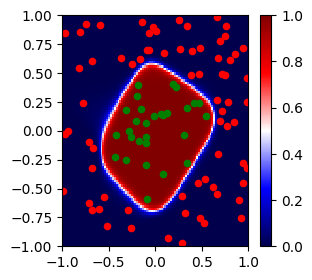

```python
# Visualización de la frontera de decisión
X1, X2 = np.meshgrid(np.linspace(-1, 1, 100), np.linspace(-1, 1, 100))
Z = sigmoid(np.dot(pesos[0].T, np.vstack([X1.ravel(), X2.ravel()])) + sesgos[0])
Z = sigmoid(np.dot(pesos[1].T, Z) + sesgos[1])

plt.figure(figsize = [3, 3])
p = plt.pcolormesh(X1, X2, Z.reshape(X1.shape), cmap = 'seismic', vmin = 0, vmax = 1)
plt.scatter(lin_cir['x1'][ceros], lin_cir['x2'][ceros], color = 'r', s=20)
plt.scatter(lin_cir['x1'][unos], lin_cir['x2'][unos], color = 'g', s=20)
plt.xlim([-1,1])
plt.ylim([-1,1])
plt.colorbar(p)
```

El momentum contribuye a una convergencia más eficiente y estable, debido a que acelerar la convergencia y evita que el modelo se estanque en mínimos locales durante el proceso de optimización. Al incorporar el momentum, se añade una fracción de la actualización de pesos anterior a la actualización actual, lo que ayuda a suavizar las oscilaciones y a mantener la dirección del descenso del gradiente. Por tal razon, si comparamos el error optimo en este caso, tenemos que es 4.04 x 10^-5 y anteriormente con la misma parametrización era 0.001.

d) Generalizar a un número arbitrario de capas (recomendación, definir los pesos como una lista de matrices, una para cada capa). Aplicar la función al ejemplo de la espiral y validar los resultados en el dominio x:[-1, 1], y [-1, 1].

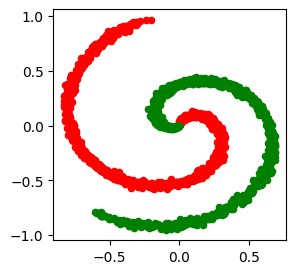

```python
# visualización de los datos
lin_spi = pd.read_csv("spiral.csv", names=['x1', 'x2', 'y'])

ceros = np.where(lin_spi['y']==0)[0];
unos = np.where(lin_spi['y']==1)[0]

plt.figure(figsize = [3, 3])
plt.scatter(lin_spi['x1'][ceros], lin_spi['x2'][ceros], color = 'r', s=20)
plt.scatter(lin_spi['x1'][unos], lin_spi['x2'][unos], color = 'g', s=20)
```

```python
# matriz de entrada y salida
a = lin_spi[['x1', 'x2']].T.values
b = lin_spi['y'].values.reshape(1, len(lin_spi['y'].values))

#Sigmoide:
def sigmoid(x):
    return 1 / (1 + np.exp(-x))
#Derivada de la sigmoide
def d_sigmoid(x):
    return sigmoid(x)*(1-sigmoid(x))
```

```python
def backprop_gen_with_momentum(a, b, h, epochs=500, eta=0.1, alpha=0.9):
    # Inicialización de matrices
    np.random.seed(1302)
    neurons = [np.shape(a)[0]] + h + [np.shape(b)[0]]
    weights = [np.random.uniform(low=-1, high=1, size=(neurons[i], neurons[i+1])) for i in range(len(neurons)-1)]
    bias = [np.random.uniform(low=-1, high=1, size=(neurons[i+1], 1)) for i in range(len(neurons)-1)]

    # Inicialización de las actualizaciones anteriores (momentum)
    prev_weight_updates = [np.zeros_like(w) for w in weights]
    prev_bias_updates = [np.zeros_like(b) for b in bias]

    errors = []

    for i in range(epochs):
        # Propagación hacia adelante
        B_hidden = [np.dot(weights[0].T, a) + bias[0]]

        for j in range(1, len(h)):
            B_hidden.append(np.dot(weights[j].T, sigmoid(B_hidden[j-1])) + bias[j])

        hidden = [sigmoid(B_hidden[j]) for j in range(len(h))]

        # Entrada ponderada de la capa de salida
        B_out = np.dot(weights[-1].T, sigmoid(B_hidden[-1])) + bias[-1]
        b_out = sigmoid(B_out)

        # Cálculo de gradiente
        # ERROR (Diferencia entre real y predicha)
        d_error = b_out - b
        error = np.mean((d_error) ** 2)
        errors.append(error)

        # BACKPROPAGATION
        # Capa de salida
        aux_delta = d_error * d_sigmoid(B_out)
        v_delta_out = np.dot(sigmoid(B_hidden[-1]), aux_delta.T)
        t_delta_out = aux_delta.sum(axis=1, keepdims=True)

        # Capas ocultas
        aux_delta_w = [np.dot(weights[-1], aux_delta) * d_sigmoid(B_hidden[-1])]
        w_delta_hidden = [np.dot(sigmoid(B_hidden[-2]) if len(h) > 1 else a, aux_delta_w[0].T)]
        b_delta_hidden = [aux_delta_w[0].sum(axis=1, keepdims=True)]

        # Resto de capas
        for j in range(1, len(h)):
            prev_activation = sigmoid(B_hidden[-j-2]) if j < len(h)-1 else a
            aux_delta_w.append(np.dot(weights[-1-j], aux_delta_w[-1]) * d_sigmoid(B_hidden[-1-j]))
            w_delta_hidden.append(np.dot(prev_activation, aux_delta_w[-1].T))
            b_delta_hidden.append(aux_delta_w[-1].sum(axis=1, keepdims=True))

        # Actualización de pesos y sesgos con momentum
        w_delta_hidden = w_delta_hidden[::-1]
        b_delta_hidden = b_delta_hidden[::-1]

        for j in range(len(h)):
            prev_weight_updates[j] = alpha * prev_weight_updates[j] - eta * w_delta_hidden[j]
            prev_bias_updates[j] = alpha * prev_bias_updates[j] - eta * b_delta_hidden[j]

            weights[j] += prev_weight_updates[j]
            bias[j] += prev_bias_updates[j]

        prev_weight_updates[-1] = alpha * prev_weight_updates[-1] - eta * v_delta_out
        prev_bias_updates[-1] = alpha * prev_bias_updates[-1] - eta * t_delta_out

        weights[-1] += prev_weight_updates[-1]
        bias[-1] += prev_bias_updates[-1]

        # Imprimir error cada 100 iteraciones
        if i % 100 == 0:
            print(f"Epoch {i}: Error = {error}")

    # Devolver los valores aprendidos
    return weights, bias, errors
```

```python
#SE definen 2 capas ocultas con número de neuronas por capa
h = [10, 8]
```

```python
#Ejecutar backpropagation
pesos_finales, sesgos_finales, errores_final = backprop_gen_with_momentum(a, b, h=h, epochs=1000, eta=0.01, alpha=0.9)
```

```
Epoch 0: Error = 0.24989690732428677
Epoch 100: Error = 0.16860410615928903
Epoch 200: Error = 0.01820909551673359
Epoch 300: Error = 0.003820159845101574
Epoch 400: Error = 0.0023250021228461448
Epoch 500: Error = 0.001783822094957511
Epoch 600: Error = 0.001485837814362462
Epoch 700: Error = 0.0012928903782843002
Epoch 800: Error = 0.0011563079000615098
Epoch 900: Error = 0.001053916929222537
```

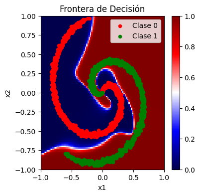

```python
def visualizar_frontera(pesos_finales, sesgos_finales, lin_spi, ceros, unos):
    # Crear grid de puntos
    X1, X2 = np.meshgrid(np.linspace(-1, 1, 100), np.linspace(-1, 1, 100))
    entrada = np.vstack([X1.ravel(), X2.ravel()])

    # Forward propagation a través de todas las capas
    Z = entrada
    for w, b in zip(pesos_finales, sesgos_finales):
        Z = sigmoid(np.dot(w.T, Z) + b)

    # Visualización
    plt.figure(figsize=[4, 4])
    p = plt.pcolormesh(X1, X2, Z.reshape(X1.shape), cmap='seismic', vmin=0, vmax=1)
    plt.scatter(lin_spi['x1'][ceros], lin_spi['x2'][ceros], color='r', s=20, label='Clase 0')
    plt.scatter(lin_spi['x1'][unos], lin_spi['x2'][unos], color='g', s=20, label='Clase 1')
    plt.xlim([-1, 1])
    plt.ylim([-1, 1])
    plt.colorbar(p)
    plt.legend()
    plt.title('Frontera de Decisión')
    plt.xlabel('x1')
    plt.ylabel('x2')
    plt.show()

visualizar_frontera(pesos_finales, sesgos_finales, lin_spi, ceros, unos)
```

En la gráfica se observa que con 2 capas de 10 y 8 neuronas, con 1000 epocas y 0.01 de tasa de aprendizaje, se obtiene un error de 0.001. Al igual que las anteriores, se puede observar la frontera de decisión para la clasifciación del problema del espiral, observando dos clases. En este sentido se podría decir que el modelo tiene una buena capacidad de separar las clases con un error de 0.001.

Se prueba la generalización de la función de varias capas con los problemas lineal y circulo.

```python
#lineal
lin = pd.read_csv("lineal.csv", names=['x1', 'x2', 'y'])
ceros = np.where(lin['y']==0)[0];
unos = np.where(lin['y']==1)[0]
a = lin[['x1', 'x2']].T.values
b = lin['y'].values.reshape(1, len(lin['y'].values))

h = [3]
pesos_finales, sesgos_finales, error_final = backprop_gen_with_momentum(a, b, h=h, epochs=1000, eta=0.1, alpha=0.9)
```

```
Epoch 0: Error = 0.28808711370205964
Epoch 100: Error = 0.006071158045615846
Epoch 200: Error = 0.002290895010889271
Epoch 300: Error = 0.001356750602839412
Epoch 400: Error = 0.0009446531015099658
Epoch 500: Error = 0.0007164458110480357
Epoch 600: Error = 0.0005729471226376191
Epoch 700: Error = 0.0004750231027242591
Epoch 800: Error = 0.00040426479713092566
Epoch 900: Error = 0.00035092621389893393
```

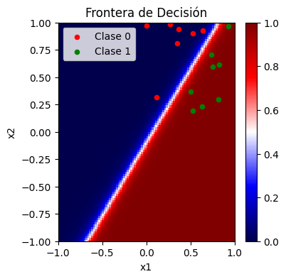

```python
visualizar_frontera(pesos_finales, sesgos_finales, lin, ceros, unos)
```

```
Epoch 0: Error = 0.24259062765953432
Epoch 100: Error = 0.14106019024111766
Epoch 200: Error = 0.0003995977971570871
Epoch 300: Error = 0.00021921602118870695
Epoch 400: Error = 0.00014766301746807782
Epoch 500: Error = 0.00010987729006533527
Epoch 600: Error = 8.67962813893355e-05
Epoch 700: Error = 7.135981657168811e-05
Epoch 800: Error = 6.037143744324195e-05
Epoch 900: Error = 5.21834972164974e-05
```

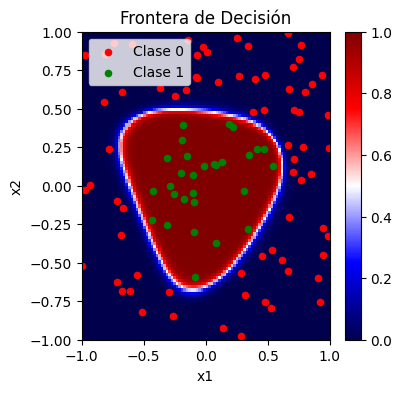

```python
#circulo
lin_cir = pd.read_csv("circle.csv", names=['x1', 'x2', 'y'])
ceros = np.where(lin_cir['y']==0)[0];
unos = np.where(lin_cir['y']==1)[0]

a = lin_cir[['x1', 'x2']].T.values
b = lin_cir['y'].values.reshape(1, len(lin_cir['y'].values))

h = [7, 5] #se ponen 2 capas ocultas pero con una de 5 neuronas se obtiene un buen resultado - se usan 2 capas para probar
pesos_finales, sesgos_finales, error_final = backprop_gen_with_momentum(a, b, h=h, epochs=1000, eta=0.1, alpha=0.9)
visualizar_frontera(pesos_finales, sesgos_finales, lin_cir, ceros, unos)
```